# PRÁCTICA 2: PROCESOS Y COMUNICACIÓN ENTRE PROCESOS

## Antes de empezar…

… júntate con tu grupo de prácticas y copia los ficheros que se encuentran en la carpeta “materiales” al directorio en el que quieras trabajar.  
Ahora ya estás preparado para comenzar la práctica.

## Objetivos de la práctica

Esta práctica tiene como objetivos entender la forma en que Unix maneja los procesos, así como practicar su uso. Esto incluye la creación de los mismos, la ejecución de programas, la comunicación entre procesos, y la forma en que procesos relacionados comparten información (especialmente memoria y ficheros) o pueden interaccionar entre ellos.

Por consiguiente, se estudiará el uso de las llamadas a sistema *fork*, *exec*, *read*, *write*, *exit*, *wait*, *signal* y *kill* mediante una serie de programas de ejemplo.

## Entrega y evaluación

El deadline para la entrega de la práctica se especifica en el campus virtual. Cualquier trabajo recibido **fuera del plazo contará como no entregado**. La entrega consistirá en un fichero comprimido **lab_2_apellidos.tar.gz**, donde *apellidos* son los primeros apellidos de los miembros del grupo separados por *_*. Por ejemplo, el grupo de Carl Gauss, Marie Curie y Rosalind Franklin entregaría *lab_2_gauss_curie_franklin.tar.gz*. Los contenidos del *tar.gz* serán:

1. La plantilla de “soluciones.txt” con los nombres de los componentes del grupo y con las respuestas a las preguntas planteadas en **Ejercicios**.  
   Las preguntas planteadas en las secciones de **Autoevaluación** son para estudio personal y **no se evaluarán**.
2. Una carpeta *code* para aquellos ejercicios que requieran código fuente. Cada ejercicio deberá estar nombrado como indique el enunciado (en general, del tipo *ejercicio-4-1.c*). Esta carpeta de **code deberá contener un makefile** que compile todos los ejercicios (consejo: no dejes la creación del *makefile* para el final).

Las prácticas que no cumplan el formato de entrega no serán evaluadas completamente. En concreto:

- Si el fichero se ha comprimido usando otro formato distinto a *.tar.gz*: la práctica no se evaluará.
- Si falta el fichero “soluciones.txt” o se entrega con otro formato: las respuestas teóricas contenidas en el mismo no serán evaluadas.
- Un programa (con los ficheros *.c y* .h) sin makefile: no será evaluado.
- Un programa con makefile que no compile: no será evaluado.

Además del ejemplo de makefile hecho en clase, se ha incluido un ejemplo sencillo de makefile dentro de la carpeta de materiales. Un ejemplo más completo se puede encontrar [aquí](https://gist.github.com/constantino-garcia/3425c31497ef5df45556ef28bdfbeb63). También puedes leer este [tutorial](http://matt.might.net/articles/intro-to-make/) o la introducción oficial a [GNU makefile](https://www.gnu.org/software/make/manual/html_node/Introduction.html).

La dificultad de los ejercicios se ha clasificado, de menor a mayor dificultad en [!], [!!] y [!!!]. Cada uno de estos ejercicios se puntuarán con 1, 2 y 3 puntos. Los ejercicios más sencillos [!] recibirán una puntuación binaria (0 o 1) por lo que deben estar perfectamente resueltos para que puntuen. La nota final sobre 10 se obtendrá mediante una regla de 3.

# Creación de procesos mediante *fork*

En Unix, un proceso es creado mediante la llamada al sistema *fork()*. El proceso que realiza la llamada se denomina proceso padre (parent process) y el proceso creado a partir de la llamada se denomina proceso hijo (child process). La sintaxis de la llamada, efectuada desde el proceso padre, es:

```c
valor = fork()
```

La llamada *fork()* devuelve un valor distinto para los procesos padre e hijo: al proceso padre se le devuelve el PID del proceso hijo, mientras que al proceso hijo se le devuelve “0”.

Las acciones que implican ejecutar un *fork()* son llevadas a cabo por el núcleo (kernel) del sistema operativo Unix. Dichas acciones son las siguientes:

1. Asignación de un hueco en la tabla de procesos para el nuevo proceso (hijo).
2. Asignación de un identificador único (PID) al proceso hijo.
3. Copia de la imagen del proceso padre al proceso hijo (con excepción de la memoria compartida).
4. Asignación al proceso hijo del estado “preparado para ejecución”.
5. Devolución de los dos valores de retorno de la función: al proceso padre se le entrega el PID del proceso hijo, y al proceso hijo se le entrega “0”.

El siguiente código, ubicado en el fichero “forkprog1.c” (carpeta de materiales), muestra el uso de la llamada a sistema *fork()*:

```c
#include <unistd.h>
            #include <stdio.h>
            #include <stdlib.h>

            int main() {
                pid_t rf;
                rf = fork();
                switch (rf) {
                    case -1:
                        printf("No he podido crear el proceso hijo \n");
                        break;
                    case 0:
                        printf("Soy el hijo, mi PID es %d y mi PPID es %d \n", getpid(), getppid());
                        sleep(20); //suspende el proceso 20 segundos
                        break;
                    default:
                        printf("Soy el padre, mi PID es %d y el PID de mi hijo es %d \n", getpid(), rf);
                        sleep(30); //suspende el proceso 30 segundos. Acaba antes el hijo.
                }
                printf("Final de ejecución de %d \n", getpid());
                exit(0);
            }
```

Compila el programa anterior usando “gcc”.

```
$ gcc -Wall -o forkprog1 forkprog1.c
```

Ejecuta el programa “forkprog1” en segundo plano (o *background*). Para ello debes añadir al nombre del programa el carácter “&” (*ampersand*).

```
$ ./forkprog1 &
```

Verifica que se está ejecutando a través del comando “ps” (tal y cómo se explicó en la práctica anterior). Dicha orden ha de ser ejecutada antes de que finalice la ejecución del proceso.

```
$ ps -l
```

Observa los valores del PID y el PPID de cada proceso e identifica qué atributos del procesos son heredados de padre a hijo y cuáles no.

## Autoevaluación

1. Anota el valor mostrado inmediatamente después de lanzar el proceso en segundo plano e indica qué representa dicho valor.
2. ¿Cuáles son los PID de los procesos padre e hijo?
3. ¿Qué realiza la función “sleep”? ¿Qué proceso concluye antes su ejecución?
4. ¿Qué ocurre cuando la llamada al sistema *fork* devuelve un valor negativo?
5. ¿Cuál es la primera instrucción que ejecuta el proceso hijo?
6. Modifica el código del programa para asegurar que el proceso padre imprime su mensaje de presentación (“Soy el padre…”) antes que el hijo imprima el suyo.
7. Usa el comando `ps -l` para averiguar el tamaño de los procesos creados. ¿Qué tamaño en memoria ocupan cada uno de ellos? ¿Por qué?

## Ejercicios (Sección 1)

1. [!!!] Implementa un árbol en C que use varias llamadas a *fork()* para crear la siguiente estructura de procesos.

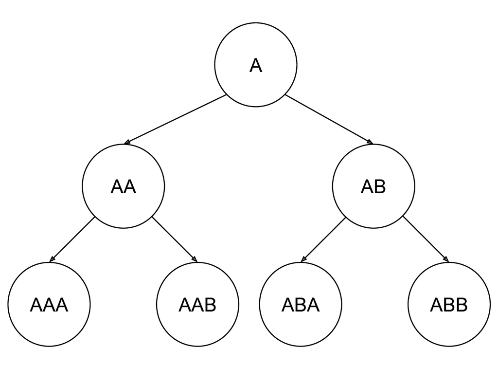

Cada proceso deberá imprimir el texto que contiene el nodo que lo identifica por pantalla rodeado de los símbolos <>. Por ejemplo, el proceso “AA” debería imprimir por pantalla `<AA>`. Cada proceso imprimirá el mensaje que le corresponda **antes** de hacer los *fork* necesarios. Usa la siguiente función en lugar de *printf* para realizar la implementación (más tarde la modificaremos).

```c
void show_message(char* message) {
               printf("<%s>\n", message);
            }
```

Realiza la programación intentando que ésta sea lo más general posible. Como mínimo, debería permitir cambiar la profundidad del árbol sin necesidad de copiar y pegar nuevo código. LLama al código fuente “ejercicio1-1.c”.

# Zonas de datos entre procesos vinculados por *fork*

Dos procesos vinculados por una llamada *fork()* (padre e hijo) poseen zonas de datos propias, de uso privado (no compartidas). Obviamente, al tratarse de procesos diferentes, cada uno posee un espacio de direcciones independiente e inviolable.

La ejecución del siguiente programa, en el cual se asigna distinto valor a una misma variable según se trate de la ejecución del proceso padre o del hijo, nos permitirá comprobar dicha característica de la llamada *fork()*.

forkprog2.c:

```c
#include <unistd.h>
            #include <stdio.h>
            #include <stdlib.h>

            int main() {
                int i;
                int j;
                pid_t rf;
                rf = fork();
                switch (rf) {
                    case -1:
                        printf("\nNo he podido crear el proceso hijo");
                        break;
                    case 0:
                        i = 0;
                        printf("\nSoy el hijo, mi PID es %d y mi variable i (inicialmente a %d) es par", getpid(), i);
                        for (j = 0; j < 5; j++) {
                            i++;
                            i++;
                            printf("\nSoy el hijo, mi variable i es %d", i);
                        };
                        break;
                    default:
                        i = 1;
                        printf("\nSoy el padre, mi PID es %d y mi variable i (inicialmente a %d) es impar", getpid(), i);
                        for (j = 0; j < 5; j++) {
                            i++;
                            i++;
                            printf("\nSoy el padre, mi variable i es %d", i);
                        }
                }
                printf("\nFinal de ejecucion de %d\n", getpid());
                exit(0);
            }
```

En el programa anterior el proceso padre va dando valores impares a su variable “i” privada, mientras que el proceso hijo va dando valores pares a su variable “i”, también privada, que es diferente a la del proceso padre.

Para ejecutar este programa es preciso compilarlo primero:

```
$ gcc -Wall -o forkprog2 forkprog2.c

            $ ./forkprog2
```

## Ejercicios (Sección 2)

1. [!] ¿Son las variables enteras “i” y “j” del proceso padre las mismas que las del proceso hijo?
2. [!] Cambia el código de “forkprog2.c” para que ambos procesos partan de una variable “i” con igual valor, pero uno la incremente de uno en uno y el otro de dos en dos. Guarda el nuevo programa como el archivo “ejercicio2-2.c”. Fíjate que este ejercicio demuestra que ambos procesos tienen zonas de memoria separadas.

# Ficheros abiertos entre procesos vinculados por *fork*

Los descriptores de ficheros (que indican qué ficheros tiene abierto un proceso) en el momento de hacer la llamada *fork()* son compartidos por los dos procesos que resultan de dicha llamada. Dicho de otra forma, los descriptores de ficheros en uso por el proceso padre son heredados por el proceso hijo generado.

En el siguiente programa, llamado “forkprog3.c”, dos procesos escriben distintas cadenas de caracteres en los mismos ficheros.

Pero antes de meternos con el programa en sí es necesario aclarar un aspecto muy importante sobre el mismo. Ambos procesos (padre e hijo) realizan escrituras (llamadas al sistema *write()*) sobre los ficheros. Estas operaciones de Entrada/Salida deberían suspenderlos y, sin embargo, ambos realizan después una llamada a *usleep()* precisamente para forzar su suspensión. La necesidad de utilizar *usleep()* proviene de cómo Linux implementa la llamada *write()*: en vez de realizar inmediatamente una escritura en disco (lo que sí produciría la suspensión del proceso), *write()* escribe los datos en una memoria intermedia (caché), que posteriormente será volcada a disco. Linux realiza está acción con la intención de agrupar varias llamadas a *write()* antes de acceder al disco, minimizando así el número de accesos. Por ello, el proceso no es obligatoriamente suspendido al utilizar *write()*.

forkprog3.c:

```c
#include <unistd.h>
            #include <stdlib.h>
            #include <stdio.h>
            #include <fcntl.h>

            int main() {
                int i;
                int fd1, fd2;
                const char string1[10]= "*********";
                const char string2[10]= "---------";
                pid_t rf;
                fd1 = creat("ficheroA", 0666);
                fd2 = creat("ficheroB", 0666);
                rf = fork();
                switch (rf) {
                    case -1:
                        printf("\nNo he podido crear el proceso hijo");
                        break;
                    case 0:
                        for (i = 0; i < 10; i++) {
                            write(fd1, string2, sizeof(string2));
                            write(fd2, string2, sizeof(string2));
                            usleep(1); /* Abandonamos voluntariamente el procesador */
                        }
                        break;
                    default:
                        for (i = 0; i < 10; i++) {
                            write(fd1, string1, sizeof(string1));
                            write(fd2, string1, sizeof(string1));
                            usleep(1); /* Abandonamos voluntariamente el procesador */
                        }
                }
                printf("\nFinal de ejecucion de %d \n", getpid());
                exit(0);
            }
```

Ejecuta el programa y observa los resultados obtenidos usando “cat”:

```bash
  gcc -Wall -o forkprog3 forkprog3.c
            ./forkprog3
            cat ficheroA
            cat ficheroB
```

## Ejercicios (Sección 3)

1. [!] La expresión “fd1 = creat(”ficheroA“, 0666)” crea un fichero, le da nombre, le asigna permisos, y lo asigna una variable entera, “fd1”, que es el descriptor de dicho fichero, utilizado por el programa para manipularlo. ¿Qué significado tiene la constante “0666”? ¿Qué permisos tienen los dos ficheros, “ficheroA” y “ficheroB”, tras la ejecución del “forkprog3.c”? ¿Por qué sucede esto? Investiga buscando el concepto de *umask*.
2. [!] La ejecución concurrente de las escrituras de los procesos padre e hijo da lugar a que las cadenas “*********” y “———” aparezcan alternadas en los ficheros resultantes. Modifica “forkprog3.c” para que, mediante la utilización de la función “sleep()”, la frecuencia a la que el proceso hijo escribe en los ficheros sea aproximadamente 5 veces menor que la del proceso padre. Es decir, cada 5 líneas escritas por el padre debería haber 1 línea escrita por el hijo (aproximadamente). Incremente el número de vueltas de los bucles para observar mejor este resultado. Guarda el nuevo programa como el archivo “ejercicio3-2.c”.
3. [!!] Prueba las siguientes variantes de la función *show_message* del “ejercicio1-1.c”:
   1. Elimina el salto de línea en el formato del mensaje: “<%s>” (ejercicio3-3-1.c).
   2. Usa la función *write* en lugar de printf para escribir en la salida estándar (ejercicio3-3-2.c).
   3. Elimina el salto de línea en el formato del mensaje: “<%s>” y haz un *fflush(stdout)* después de realizar el *printf* (ejercicio3-3-3.c).

   Al menos uno de los cambios anteriores hará que el funcionamiento del programa no sea el esperado. Especifica cuál e intenta explicar los motivos por los que se comporta así (y por qué las otras variantes no). Puedes discutir con tus profesores si te encuentras atascado.

# Espera del proceso padre al proceso hijo

## Ejecución con espera

En el siguiente programa, llamado “espe1.c”, se emplea la llamada al sistema *wait()*. Esta llamada hace que el proceso que la invoca quede suspendido hasta que termine alguno de sus procesos hijos.

espe1.c:

```c
            #include <unistd.h>
            #include <stdlib.h>
            #include <stdio.h>
            #include <wait.h>

            int main() {
                pid_t rf;
                rf = fork();
                switch (rf) {
                    case -1:
                        printf("\nNo he podido crear el proceso hijo");
                        break;
                    case 0:
                        printf("Soy el hijo, mi PID es %d y mi PPID es %d\n", getpid(), getppid());
                        sleep(10);
                        break;
                    default:
                        printf("Soy el padre, mi PID es %d y el PID de mi hijo es %d\n", getpid(), rf);
                        wait(0);
                }
                printf("\nFinal de ejecucion de %d \n", getpid());
                exit(0);
            }
```

Compila y ejecuta el programa:

```
$ gcc -Wall -o espe1 espe1.c

            $ ./espe1 &

            $ ps -l
```

## Ejecución sin espera

En el siguiente programa, llamado “espe2.c”, no se emplea la llamada al sistema *wait()*, pero por lo demás es idéntico al anterior.

espe2.c:

```c
#include <unistd.h>
            #include <stdlib.h>
            #include <stdio.h>

            int main() {
                pid_t rf;
                rf = fork();
                switch (rf) {
                    case -1:
                        printf("\nNo he podido crear el proceso hijo");
                        break;
                    case 0:
                        printf("\nSoy el hijo, mi PID es %d y mi PPID es %d", getpid(), getppid());
                        sleep(10);
                        break;
                    default:
                        printf("\nSoy el padre, mi PID es %d y el PID de mi hijo es %d", getpid(), rf);
                }
                printf("\nFinal de ejecucion de %d \n", getpid());
                exit(0);
            }
```

Compila y ejecuta este programa:

```
$ gcc -Wall -o espe2 espe2.c

            $ espe2 &

            $ ps -l
```

## Ejercicios (Sección 4)

1. [!] Al ejecutar “espe2.c”, ¿cuál es el PPID del proceso hijo, una vez el padre ha finalizado? ¿Por qué?
2. [!] Modifica el código del programa “espe2.c” para que sea el proceso padre quien se muere después del hijo añadiendo o quitando *sleeps*. Monitoriza los estados de los procesos mientras se ejecuta el programa. ¿Aparece algún estado curioso?¿Por qué es necesario este estado? (Consulta a tus profesores si no ves este estado). Guarda el nuevo programa como el archivo “ejercicio4-2.c”.
3. [!] Modifica el código del programa “espe2.c” para que el proceso padre imprima el mensaje de finalización de su ejecución *exactamente* 10 segundos más tarde de que se muera el proceso hijo usando *wait* y *sleep*. ¿Qué ocurre ahora con el estado visto en el apartado anterior? ¿Por qué ocurre esto? Guarda el nuevo programa como el archivo “ejercicio4-3.c”.

# Inicio de programas mediante *exec*

La llamada *exec()* sustituye el programa que la invoca por un nuevo programa. Mientras que *fork()* crea nuevos procesos, *exec()* sustituye la imagen en memoria del proceso por otra nueva (es decir, que sustituye todos los elementos del proceso: código del programa, datos, pila y heap).

El PID del proceso es el mismo que antes de realizar la llamada *exec()*, pero ahora ejecuta otro programa. El proceso pasa a ejecutar el nuevo programa desde el inicio y la imagen en memoria del antiguo programa se pierde al verse sobrescrita. La imagen en memoria del antiguo programa se pierde para siempre, es decir, todo el código que escribamos posteriormente a la ejecución con éxito de la llamada *exec()* será inalcanzable.

La combinación de las llamadas *fork()* y *exec()* es el mecanismo que ofrece Unix para la creación de un nuevo proceso (*fork()*) que ejecute un programa determinado (*exec()*).

De las posibles llamadas tipo *exec()* (ver fichero en materiales ‘llamadas_exec.pdf’) usaremos para este apartado de la práctica la llamada “execv()”, cuya sintaxis es:

```
int execv(const char *filename, char *const argv[ ]);
```

Podemos seguir la ejecución del proceso gracias a la orden “ps”, usándola justo antes y justo después de la llamada “execv()”, comprobando así cómo se efectúa la sustitución de la imagen de memoria. El nuevo programa activado mantiene el mismo PID, así como otras propiedades asociadas al proceso. Sin embargo, el tamaño en memoria de la imagen del proceso cambia, dado que el programa en ejecución es diferente.

En este apartado se va a practicar con dos programas (“execprog1” y “execprog2”), cuyos ficheros fuente (“execprog1.c” y “execprog2.c”) se muestran a continuación.

execprog1.c:

```c
#include <stdio.h>
            #include <unistd.h>
            #include <string.h>
            #include <stdlib.h>

            int main (int argc, char *argv[]) {
                int i;
                printf("Ejecutando el programa invocador (execprog1). Sus argumentos son:\n");
                for (i = 0; i < argc; i++)
                    printf("argv[%d]: %s\n", i, argv[i]);
                sleep(10);
                strcpy(argv[0], "execprog2");
                if (execv ("./execprog2", argv) < 0) {
                    printf("Error en la invocacion a execprog2\n");
                    exit(1);
                };
                exit(0);
            }
```

execprog2.c:

```c
#include <stdio.h>
            #include <unistd.h>
            #include <stdlib.h>

            int main (int argc, char *argv[]) {
                int i;
                char a[2000000];
                printf("Ejecutando el programa invocado (execprog2). Sus argumentos son:\n");
                for (i = 0; i < argc; i++)
                    printf("argv[%d]: %s\n", i, argv[i]);
                sleep(10);
                exit(0);
            }
```

Compila los programas “execprog1.c” y “execprog2.c” usando “gcc”.

```
$ gcc -Wall -o execprog1 execprog1.c

            $ gcc -Wall -o execprog2 execprog2.c
```

Ejecuta en *background* (añadiendo “&”) el programa “execprog1”, para poder verificar su ejecución usando la orden “ps”. La forma de invocar el programa “execprog1” es la siguiente:

```
$ ./execprog1 arg1 arg2 ... argN &

            $ ps -l
```

## Autoevaluación

1. Escribe el contenido de los elementos del vector “argv” que recibe “execprog1” y los que recibe “execprog2”.
2. ¿Qué PID tiene el proceso que ejecuta “execprog1.c”? ¿Y el que ejecuta “execprog2.c”?
3. Modifica el programa “execprog1.c” para introducir código inalcanzable (printf(“Hola”);) y comprueba que, efectivamente no se alcanza.
4. ¿Puede la última línea de “execprog1.c” (exit(0);) llegar a ejecutarse alguna vez?
5. ¿Qué tamaño de memoria ocupa el proceso, según ejecute “execprog1” o “execprog2”? ¿Por qué?

## Ejercicios (Sección 5)

1. [!!!] Crea un programa (“ejercicio5-1.c”) que se le pase una lista de nombres de archivos y que para cada archivo *file* cree un nuevo proceso usando *fork* + *execv* (o algún miembro de su familia) que se encargue de hacer un backup de dicho archivo *file.bak*. Fíjate que el uso de varios procesos actuando en paralelo puede acelerar el proceso de backup. Como primer paso para la resolución del ejercicio reflexiona acerca de qué programa podrías emplear para realizar una copia de un archivo.

## Autoevaluación

1. Escribe un script de Bash que haga exactamente lo mismo que ejercicio5-1. Para crear copias en paralelo, manda los procesos encargados de la copia a *background* con `&`.

# Manejo de señales

El programa “signal.c” hace uso de la llamada a sistema *signal()* para cambiar su comportamiento con respecto a las señales recibidas.

signal.c:

```c
#include <unistd.h>
            #include <stdlib.h>
            #include <signal.h>
            #define VUELTAS 10000000000LL

            void confirmar(int sig) {
                char resp[100];
                write(1, "Quiere terminar? (s/n):", 24);
                read(0, resp, 100);
                if (resp[0]=='s') exit(0);
            }

            int main(void) {
                long long int i;
                signal(SIGINT, SIG_IGN);
                write(1, "No hago caso a CONTROL-C\n", 25);
                for (i=0; i<VUELTAS; i++);
                signal(SIGINT, SIG_DFL);
                write(1, "Ya hago caso a CONTROL-C\n", 25);
                for (i=0; i<VUELTAS; i++);
                signal(SIGINT, confirmar);
                write(1, "Ahora lo que digas\n", 19);
                for (i=0; i<VUELTAS; i++);
                exit(0);
            }
```

Compila el programa y ejecútalo, intentando abortarlo en varios momentos usando la combinación de teclas CTRL-C. Si los tiempos de los bucles son demasiado cortos o demasiado largos para la máquina en la que estás ejecutando el programa, ajusta el contador de los bucles.

Vuélvelo a ejecutar, pero esta vez mándale la señal de interrupción desde otro terminal, en lugar de usando CTRL-C, para así comprobar que el comportamiento es equivalente. Para ello puedes usar el comando “kill”:

```
kill -SIGINT proceso
```

## Autoevaluación

1. ¿Para qué sirve cada uno de los parámetros de la función “signal()”?

## Ejercicios (Sección 6)

1. [!] Modifica el programa para que si se le manda la señal de terminar (SIGTERM) escriba el mensaje “No quiero terminar” y continúe ejecutándose. Guarda el nuevo programa como el archivo “ejercicio6-1.c”.

Ejecuta el programa modificado y envíale la señal SIGTERM. ¿Qué comando has utilizado para hacerlo?

# Envío de señales entre procesos

Los procesos se pueden enviar señales unos a otros mediante la llamada al sistema *kill()*, observa a continuación el programa “sacrificio.c”, que hace uso de esta llamada a sistema.

sacrificio.c:

```c
#include <sys/types.h>
            #include <unistd.h>
            #include <stdio.h>
            #include <stdlib.h>
            #include <signal.h>

            void hijo(int sig) {
                printf("\t\t¡Padre! ¿Qué haces?\n");
                printf("\t\tFinal de ejecución de %d \n", getpid());
                kill(getppid(), SIGUSR1);
                exit(0);
            }

            void padre(int sig) {
                printf("\t¡Hijo! ¿Qué he hecho?\n");
                printf("\tFinal de ejecución de %d \n", getpid());
                exit(0);
            }

            int main(void) {
                long long int i;
                pid_t rf;
                rf = fork();
                switch (rf) {
                    case -1:
                        printf("No he podido crear el proceso hijo. \n");
                        break;
                    case 0:
                        printf("\t\tSoy Isaac, mi PID es %d y mi PPID es %d. \n", getpid(), getppid());
                        signal(SIGUSR1, hijo);
                        pause(); // Espera a una señal
                        break;
                    default:
                        printf("\tSoy Abraham, mi PID es %d y el PID de mi hijo es %d. \n", getpid(), rf);
                        signal(SIGUSR1, padre);
                        sleep(1);   //suspende el proceso 1 segundo.
                        printf("\tVoy a matar a mi hijo.\n");
                        sleep(15);  //suspende el proceso 15 segundos.
                        kill(rf, SIGUSR1);
                        sleep(1);
                }
                exit(0);
            }
```

Aunque puede enviarse cualquier señal usando *kill()*, hay dos señales de propósito general sin un uso predeterminado disponibles: SIGUSR1 y SIGUSR2. El programa mostrado hace uso de la primera de ellas.

Compila y ejecuta el programa, observando qué ocurre.

## Autoevaluación

1. ¿Cuántas señales se han enviado?, ¿de qué proceso a qué proceso?, ¿en qué orden?

## Ejercicios (Sección 7)

1. [!!] Modifica el programa “sacrificio.c” para permitir la intervención divina. Esta será en forma de la señal SIGUSR2. Al recibir esta señal, el proceso padre ejecutará una función nueva llamada “dios”, que deberá imprimir por pantalla la frase “El Señor ha intervenido!, ¡se ha interrumpido el sacrificio!”, y después terminar la ejecución del proceso mediante “exit(0)”. Guarda el nuevo programa como el archivo “ejercicio7-1.c”.

Compila y ejecuta el programa modificado. Ahora debes actuar como ser divino enviando la señal SIGUSR2 al proceso padre usando el terminal durante los 15 segundos de margen que tienes antes de que se produzca el sacrificio. Si todo ha salido bien, el proceso hijo no debería ser sacrificado. ¿Qué comando has utilizado?

# Comunicación mediante tuberías (*pipes*)

Las tuberías o *pipes* sirven para comunicar dos procesos, de tal forma que uno de ellos escribe en una tubería, mientras que el otro lee de ella. En Unix, además de poder conectar dos procesos mediante una tubería usando el carácter “|”, también podemos crear un tipo de tubería conocida como “*pipe* con nombre” de forma explícita. Estas tuberías reciben el apelativo de “con nombre” porque, a diferencia de las creadas usando “|”, su existencia persiste más allá de la ejecución de los procesos que la usan. Por tanto, deben ser borradas de forma explícita.

Como las pipes con nombre se comportan como una cola FIFO, también suelen recibir este nombre.

Crea una nueva *pipe* usando el siguiente comando:

```
mkfifo pruebafifo
```

Las *pipes* son manejadas por el sistema operativo como archivos, algo habitual (como seguro ya sabrás) en Unix. Puedes ver la *pipe* que acabas de crear haciendo un simple listado del directorio actual:

```
ls -al
```

Haz de la *pipe* la entrada estándar de un programa. Como, por ejemplo, de un “sort”:

```
sort < pruebafifo
```

Fíjate en que “sort” por sí mismo no hace nada. Abre otra ventana de terminal y escribe en ella lo siguiente:

```
cat > pruebafifo
```

Ahora teclea unas cuantas líneas de texto y, cuando hayas acabado, pulsa CTRL-D.

## Autoevaluación

1. Explica lo que ha sucedido.
2. Ahora haz justo lo contrario, ejecuta primero la línea del “cat”, después escribe unas cuantas líneas de texto, terminando con CTRL+D y, por último, ejecuta el “sort”. Explica qué ha sucedido.
3. ¿Qué comando deberías escribir para eliminar la *pipe* que has creado?

Los pipes también se pueden usar dentro de un programa C. Estudia el siguiente ejemplo “pipes.c”.

```c
#include <stdio.h>
            #include <stdlib.h>
            #include <unistd.h>
            #include <fcntl.h>

            int main(int argc, char* argv[]) {
              int fd[2];
              pid_t childpid;
              // Creamos el pipe, el array fd se usa para devolver 2 descriptores de fichero
              // que hacen referencia al principio y final del pipe
              pipe(fd);

              if ((childpid = fork()) == 0) {
                // El hijo va a ser ls
                // dup2 crea una copia del fichero apuntado por fd[1] usando el descriptor
                // de fichero STDOUT_FILENO. Es decir, tras dup2, la salida estándar de este
                // proceso coincidirá con la salida del pipe y los dos pueden usarse
                // independientemente
                dup2(fd[1], STDOUT_FILENO);
                close(fd[0]); // ls no va a usar la entrada del pipe
                close(fd[1]); // ls va a usar como salida STDOUT_FILENO, que es una copia de fd[1]. Podemos cerrar esta copia
                execl("/bin/ls", "ls", "-l", NULL);
                perror("Fallo en ls");
              } else {
                // hacemos que la entrada estándar sea una copia del extremo de lectura del pipe
                dup2(fd[0], STDIN_FILENO);
                close(fd[0]); // cerramos fd[0], ya que ya hemos mapeado este extremo del pipe a STDIN
                close(fd[1]); // sort no va a hacer uso del extremo de escritura
                execl("/usr/bin/sort", "sort", "-k9", NULL);
                perror("Fallo en sort");
              }
              exit(0);
            }
```

## Ejercicios (Sección 8)

1. [!!!] Crea un programa (*ejercicio8-1.c*) que cree dos procesos. El proceso padre pedirá al usuario un mensaje por entrada estándar. Cuando el usuario escriba dicho mensaje, se enviará mediante una tubería al proceso hijo, que se encargará de imprimirlo por la salida estándar. El proceso terminará cuando el usuario introduzca la cadena “FIN”.

## Autoevaluación

1. Monitoriza los estados de *ejercicio8-1*. ¿Qué estados puedes ver?

## Ejercicio final (Voluntario para subir nota)

1. [!!!] Crea un programa (ejercicio_final.c) que realice varios cálculos relacionados con números primos. En concreto:
- El programa principal recibirá por línea de comandos 2 números naturales a y b. Por ejemplo: 3 y 8.
- El programa principal creará 2 procesos hijos.
  - El padre de ellos calculará la lista de los números primos entre ambos números. En el ejemplo: 3, 5, y 7. La lista se imprimirá por pantalla.
  - El primer hijo decidirá si el número menor es un primo de Mersenne o no (la definición, más abajo) e informará mediante *exit* al padre. Este proceso no imprimirá nada por pantalla. En el ejemplo, 3 sí es primo de Mersenne.
  - El segundo hijo decidirá si el número mayor es primo de Mersenne y también informará mediante *exit* al padre, sin imprimir nada por pantalla. En el ejemplo, 8 no es primo de Mersenne.
- El proceso padre imprimirá los resultados de los procesos respetando el orden esbozado en el punto anterior. Es decir, primero se imprimirá la lista de números primos, luego si el número menor es primo de Mersenne o no, y finalmente si el número mayor es primo de Mersenne o no. La salida de nuestro ejemplo debería ser análoga a:

```bash
$ ./ejercicio_final 3 8
                La lista de números primos es: 3 5 7
                3 es un primo de Mersenne
                8 NO es un primo de Mersenne
```

- Para comprobar si un entero es primo o no puedes emplear la siguiente función:

```c
int is_prime(int n){
              int i, flag = 0;
              for(i = 2; i <= n/2; i++) {
                if(n % i == 0) {
                  flag = 1;
                  break;
                }
              }
              return (flag == 0);
            }
```

- Un número primo de Mersenne es un número primo *n* que se puede escribir como: *n* = 2<sup>*p*</sup> − 1, donde p es un número entero. Los primeros números de Mersenne son: $3, 7, 31, 127, 8191, ...$
- Para comprobar si un primo es de Mersenne procederemos en dos pasos:
  - Comprobar si *n* es primo o no.
  - Si *n* es primo, comprobar si el *p* que resulta de la ecuación anterior es entero:

```c
int is_mersenne_prime(int n) {
                int is_pr, is_int;
                double tolerance = 1e-5;
                double p;
                is_pr = is_prime(n);
                if (is_pr == 1) {
                    p = log2(n + 1);
                    // Comprobar si p es entero o no
                    return (fabs(p - (int)(p)) <= (tolerance));
                } else {
                    return 0;
                }
            }
```

Para compilar la función *is_mersenne_prime* serä necesario linkar con la librería matemática de C. Usa `gcc -lm ...`.

- En nuestro ejemplo, el proceso padre comprobará si cada uno de los números comprendidos entre los especificados por el usuario son primos. Es decir, comprobará si a=3 y b=8 son primos, realizando parte del trabajo de los hijos. Para evitar volver a hacer cálculos acerca de si a y b son primos o no, el proceso padre informará a sus hijos mediante señales si los números a y b son primos o no. De esta forma, para comprobar si el primo es de Mersenne o no, los hijos solo deben chequear la condición referente a que el exponente sea entero.